# Aspettativa_di_vita

| [*Home*](https://antonio-catalano.github.io/) | [*About*](https://antonio-catalano.github.io/about.html) | [*Archive*](https://antonio-catalano.github.io/Archive.html) |  |
| --- | --- | --- | --- |

## Importiamo un database relativo a numerosi indicatori che riguardano tutti i Paesi del mondo e zone strategiche, relativamente al periodo tra il 1960 e il 2016.

Cerchiamo di ordinare il database e di organizzarlo in maniera tale che sia chiaro nella sua visualizzazione. Qui sotto ad es. vediamo le prime 10 righe del database, che riguardano il mondo arabo. La dimensione del database è rilevante, per cui andremo a ricercare solo ciò che ci interessa.

```python
import numpy as np, pandas as pd
import matplotlib.pyplot as plt
```

```python
pd.set_option('display.float_format', lambda x: '%.2f' % x)
df2 = pd.read_csv("D:\\Admin_1\\Download\\DataWorld\\Health\\HNP_StatsData.csv")

df2 = df2.drop('Indicator Code', axis = 1)
df2 = df2.reindex(columns = df2.columns[:-2])

df2 = df2.set_index('Country Name')
df2 = df2.drop('Country Code', axis=1)
df2 = df2.dropna()
df2.head(10)
```

| Country Name | Indicator Name | 1960 | 1961 | 1962 | 1963 | 1964 | 1965 | 1966 | 1967 | 1968 | ... | 2007 | 2008 | 2009 | 2010 | 2011 | 2012 | 2013 | 2014 | 2015 | 2016 |
| --- | --- | --- | --- | --- | --- | --- | --- | --- | --- | --- | --- | --- | --- | --- | --- | --- | --- | --- | --- | --- | --- |
| Arab World | Adolescent fertility rate (births per 1,000 wo... | 134.22 | 134.84 | 135.57 | 135.44 | 135.27 | 134.95 | 134.23 | 133.36 | 130.87 | ... | 50.54 | 50.32 | 50.10 | 49.90 | 49.72 | 49.54 | 49.11 | 48.65 | 48.11 | 47.44 |
| Arab World | Age dependency ratio (% of working-age populat... | 88.21 | 89.64 | 90.94 | 92.06 | 92.89 | 93.36 | 94.24 | 94.63 | 94.69 | ... | 65.28 | 64.24 | 63.37 | 62.69 | 62.34 | 62.17 | 62.12 | 62.09 | 62.02 | 62.06 |
| Arab World | Age dependency ratio, old | 6.60 | 6.71 | 6.81 | 6.88 | 6.94 | 6.97 | 7.03 | 7.07 | 7.09 | ... | 6.77 | 6.72 | 6.69 | 6.68 | 6.70 | 6.73 | 6.78 | 6.84 | 6.93 | 7.05 |
| Arab World | Age dependency ratio, young | 81.47 | 82.78 | 83.95 | 84.93 | 85.64 | 86.04 | 86.83 | 87.20 | 87.28 | ... | 56.73 | 55.65 | 54.76 | 54.07 | 53.70 | 53.52 | 53.46 | 53.40 | 53.28 | 53.24 |
| Arab World | Birth rate, crude (per 1,000 people) | 47.69 | 47.47 | 47.25 | 47.01 | 46.77 | 46.50 | 46.20 | 45.87 | 45.51 | ... | 27.47 | 27.49 | 27.54 | 27.56 | 27.53 | 27.41 | 27.19 | 26.86 | 26.43 | 25.93 |
| Arab World | Death rate, crude (per 1,000 people) | 19.85 | 19.38 | 18.92 | 18.46 | 17.99 | 17.53 | 17.07 | 16.63 | 16.20 | ... | 5.97 | 5.90 | 5.85 | 5.81 | 5.77 | 5.73 | 5.69 | 5.64 | 5.60 | 5.55 |
| Arab World | Female population 00-04 | 8075488.00 | 8301776.00 | 8539098.00 | 8790936.00 | 9050881.00 | 9321613.00 | 9653417.00 | 9937527.00 | 10189392.00 | ... | 20188285.00 | 20593603.00 | 21041436.00 | 21553856.00 | 22153189.00 | 22797412.00 | 23440154.00 | 23992014.00 | 24396245.00 | 24838168.00 |
| Arab World | Female population 05-09 | 6433024.00 | 6705488.00 | 6949622.00 | 7155586.00 | 7332680.00 | 7498172.00 | 7742071.00 | 8005468.00 | 8274426.00 | ... | 18347718.00 | 18589503.00 | 18871106.00 | 19166579.00 | 19533076.00 | 19934561.00 | 20365061.00 | 20822332.00 | 21300406.00 | 21792616.00 |
| Arab World | Female population 10-14 | 5081009.00 | 5290554.00 | 5529461.00 | 5796963.00 | 6075198.00 | 6336142.00 | 6543357.00 | 6747068.00 | 6954845.00 | ... | 17753144.00 | 17793201.00 | 17851444.00 | 17939598.00 | 18062052.00 | 18236105.00 | 18460152.00 | 18732154.00 | 19049977.00 | 19353650.00 |
| Arab World | Female population 15-19 | 4110025.00 | 4223706.00 | 4360598.00 | 4520075.00 | 4703402.00 | 4913719.00 | 5134717.00 | 5389122.00 | 5661353.00 | ... | 17298520.00 | 17426859.00 | 17515558.00 | 17572221.00 | 17567890.00 | 17551725.00 | 17546553.00 | 17579345.00 | 17667922.00 | 17794278.00 |

10 rows × 58 columns

La prima cosa che possiamo fare è mirare l'attenzione sul nostro Paese.  
Qui sotto vediamo i primi 5 indicatori presenti nel database, relativi all'Italia.

```python
italia = df2.loc['Italy']
italia.head()
```

| Country Name | Indicator Name | 1960 | 1961 | 1962 | 1963 | 1964 | 1965 | 1966 | 1967 | 1968 | ... | 2007 | 2008 | 2009 | 2010 | 2011 | 2012 | 2013 | 2014 | 2015 | 2016 |
| --- | --- | --- | --- | --- | --- | --- | --- | --- | --- | --- | --- | --- | --- | --- | --- | --- | --- | --- | --- | --- | --- |
| Italy | Adolescent fertility rate (births per 1,000 wo... | 19.19 | 19.92 | 20.65 | 21.59 | 22.53 | 23.47 | 24.41 | 25.34 | 26.24 | ... | 6.91 | 6.80 | 6.70 | 6.59 | 6.49 | 6.38 | 6.32 | 6.27 | 6.21 | 6.16 |
| Italy | Age dependency ratio (% of working-age populat... | 52.83 | 53.01 | 53.03 | 52.98 | 53.03 | 53.23 | 53.69 | 54.13 | 54.60 | ... | 51.55 | 51.85 | 52.21 | 52.69 | 53.37 | 54.13 | 54.93 | 55.73 | 56.47 | 57.03 |
| Italy | Age dependency ratio, old | 14.51 | 14.73 | 14.93 | 15.13 | 15.33 | 15.56 | 15.87 | 16.18 | 16.52 | ... | 30.18 | 30.47 | 30.82 | 31.30 | 31.91 | 32.63 | 33.43 | 34.24 | 34.99 | 35.66 |
| Italy | Age dependency ratio, young | 38.32 | 38.28 | 38.10 | 37.86 | 37.70 | 37.67 | 37.82 | 37.95 | 38.08 | ... | 21.36 | 21.38 | 21.39 | 21.39 | 21.46 | 21.49 | 21.50 | 21.49 | 21.48 | 21.37 |
| Italy | Age population, age 0, female, interpolated | 430812.00 | 446586.00 | 458078.00 | 465062.00 | 467806.00 | 466769.00 | 461074.00 | 450973.00 | 438738.00 | ... | 279443.00 | 278375.00 | 274986.00 | 269267.00 | 261926.00 | 252225.00 | 241837.00 | 233059.00 | 227495.00 | 226314.00 |

5 rows × 58 columns

Studiamo l'indicatore relativo all'aspettativa di vita in Italia, e il suo andamento dal 1960 al 2016.  
Come possiamo vedere qui sotto, si è passati da un'aspettativa di vita di 69 anni, ad una di 82 anni e 6 mesi.  
Un incremento quindi di piu' di 13 anni.

```python
italia[italia['Indicator Name'] == 'Life expectancy at birth, total (years)']
```

| Country Name | Indicator Name | 1960 | 1961 | 1962 | 1963 | 1964 | 1965 | 1966 | 1967 | 1968 | ... | 2007 | 2008 | 2009 | 2010 | 2011 | 2012 | 2013 | 2014 | 2015 | 2016 |
| --- | --- | --- | --- | --- | --- | --- | --- | --- | --- | --- | --- | --- | --- | --- | --- | --- | --- | --- | --- | --- | --- |
| Italy | Life expectancy at birth, total (years) | 69.12 | 69.76 | 69.15 | 69.25 | 70.31 | 70.17 | 70.93 | 70.96 | 70.78 | ... | 81.43 | 81.49 | 81.64 | 82.04 | 82.19 | 82.24 | 82.69 | 83.09 | 82.54 | 82.54 |

1 rows × 58 columns

Confrontiamo la nostra aspettativa di vita con quella nel mondo. Per fare questo prendiamo l'indicatore in questione per tutti i Paesi.  
Sotto vediamo i primi 5 Paesi o Zone Strategiche presenti nel database.

```python
world = df2[df2['Indicator Name']=='Life expectancy at birth, total (years)']
print('Sono presenti {} Paesi o Zone strategiche nel database relativamente a questo indicatore.'.format(len(world.index)))
print('Queste le prime 5 Zone strategiche:')
world.head()
```

```
Sono presenti 230 Paesi o Zone strategiche nel database relativamente a questo indicatore.
Queste le prime 5 Zone strategiche:
```

| Country Name | Indicator Name | 1960 | 1961 | 1962 | 1963 | 1964 | 1965 | 1966 | 1967 | 1968 | ... | 2007 | 2008 | 2009 | 2010 | 2011 | 2012 | 2013 | 2014 | 2015 | 2016 |
| --- | --- | --- | --- | --- | --- | --- | --- | --- | --- | --- | --- | --- | --- | --- | --- | --- | --- | --- | --- | --- | --- |
| Arab World | Life expectancy at birth, total (years) | 46.83 | 47.41 | 47.99 | 48.57 | 49.16 | 49.74 | 50.32 | 50.88 | 51.42 | ... | 69.42 | 69.65 | 69.85 | 70.04 | 70.22 | 70.41 | 70.60 | 70.79 | 70.99 | 71.20 |
| Caribbean small states | Life expectancy at birth, total (years) | 62.37 | 62.87 | 63.33 | 63.74 | 64.11 | 64.44 | 64.73 | 65.00 | 65.25 | ... | 71.58 | 71.82 | 72.04 | 72.25 | 72.44 | 72.62 | 72.78 | 72.93 | 73.06 | 73.19 |
| Central Europe and the Baltics | Life expectancy at birth, total (years) | 67.82 | 68.26 | 68.01 | 68.70 | 69.05 | 69.28 | 69.53 | 69.27 | 69.54 | ... | 74.25 | 74.58 | 74.93 | 75.30 | 75.89 | 75.99 | 76.36 | 76.69 | 76.59 | 76.60 |
| Early-demographic dividend | Life expectancy at birth, total (years) | 45.21 | 45.88 | 46.49 | 47.04 | 47.64 | 48.23 | 48.87 | 49.44 | 49.98 | ... | 66.85 | 67.22 | 67.59 | 67.96 | 68.31 | 68.64 | 68.96 | 69.25 | 69.52 | 69.77 |
| East Asia & Pacific | Life expectancy at birth, total (years) | 48.46 | 48.99 | 49.66 | 50.64 | 51.84 | 53.22 | 54.75 | 56.24 | 57.62 | ... | 73.76 | 73.98 | 74.21 | 74.38 | 74.55 | 74.74 | 74.92 | 75.09 | 75.25 | 75.40 |

5 rows × 58 columns

```python
def f(df):
    return df['2016']-df['1960']
```

Sotto c'è la lista dei Paesi in cui piu' è aumentata l'aspettativa di vita dal 1960 al 2016.  
Nelle Maldive è aumentata quasi di 40 anni, un incremento enorme.  
Da notare che in questa lista non c'è nessun Paese del mondo Occidentale: la mia personale conclusione (bisogna essere cauti quando si traggono conclusioni relativi a un sistema complesso) è che se è vero che esiste la globalizzazione, allora l'economia globalizzata ha aiutato molto di piu' i Paesi poveri o che prima erano reputati del Terzo Mondo, rispetto ai Paesi occidentali.  
Dal punto di vista del fattore "sopravvivenza" questo è certo. Dal punto di vista di altri fattori non è scontato, ma il fattore "sopravvivenza maggiore" non è un fattore qualunque a mio avviso.  
Certamente aiuterebbe sapere esattamente la distribuzione spazio-temporale di conflitti bellici per capire se ad es. un incremento importante dell'aspettativa di vita è conseguenza diretta della fine di un conflitto degli anni 50-60' in quella zona geografica oppure il fattore "guerra" non è presente come determinante di un aumento di vita attesa in quella zona.

```python
f(world).sort_values(ascending=False).to_frame(name='Incremento aspettativa di vita dal 1960 al 2016').head(20)
```

| Country Name | Incremento aspettativa di vita dal 1960 al 2016 |
| --- | --- |
| Maldives | 39.94 |
| Bhutan | 35.67 |
| Timor-Leste | 35.15 |
| Nepal | 35.06 |
| Oman | 34.36 |
| Tunisia | 33.71 |
| China | 32.53 |
| Afghanistan | 31.38 |
| Iran, Islamic Rep. | 31.01 |
| Yemen, Rep. | 30.59 |
| Turkey | 30.39 |
| Algeria | 29.94 |
| Mali | 29.77 |
| Libya | 29.33 |
| Gambia, The | 29.16 |
| Korea, Rep. | 29.02 |
| Senegal | 28.92 |
| Saudi Arabia | 28.92 |
| East Asia & Pacific (IDA & IBRD countries) | 28.88 |
| East Asia & Pacific (excluding high income) | 28.77 |

A conferma della tabella precedente, vediamo qui sotto il decorso dell'aspettativa di vita delle Maldive, Paese dove piu' è aumentata l'aspettativa di vita.

```python
maldive = df2.loc['Maldives']
maldive[maldive['Indicator Name'] == 'Life expectancy at birth, total (years)']
```

| Country Name | Indicator Name | 1960 | 1961 | 1962 | 1963 | 1964 | 1965 | 1966 | 1967 | 1968 | ... | 2007 | 2008 | 2009 | 2010 | 2011 | 2012 | 2013 | 2014 | 2015 | 2016 |
| --- | --- | --- | --- | --- | --- | --- | --- | --- | --- | --- | --- | --- | --- | --- | --- | --- | --- | --- | --- | --- | --- |
| Maldives | Life expectancy at birth, total (years) | 37.40 | 37.99 | 38.63 | 39.28 | 39.96 | 40.64 | 41.34 | 42.05 | 42.76 | ... | 75.27 | 75.65 | 75.92 | 76.11 | 76.26 | 76.40 | 76.57 | 76.78 | 77.04 | 77.34 |

1 rows × 58 columns

I Paesi dove l'aspettativa di vita è aumentata di meno negli ultimi 56 anni invece sono elencati nella lista di sotto:  
L'Europa dell'Est è presente in maniera evidente in questa lista.

```python
f(world).sort_values().to_frame(name='Incremento aspettativa di vita dal 1960 al 2016').head(10)
```

| Country Name | Incremento aspettativa di vita dal 1960 al 2016 |
| --- | --- |
| Ukraine | 3.18 |
| Lithuania | 4.47 |
| Latvia | 4.74 |
| Bulgaria | 5.37 |
| Russian Federation | 5.54 |
| Belarus | 6.12 |
| Guyana | 6.39 |
| Slovak Republic | 6.64 |
| Hungary | 7.57 |
| Lesotho | 7.57 |

L'aspettativa di vita nel mondo è aumentata di quasi 20 anni dal 1960 al 2016, da 52 anni e 6 mesi a 72 anni.

.

```python
overall = df2.loc['World']
expected_world = overall[overall['Indicator Name']== 'Life expectancy at birth, total (years)']
expected_world
```

| Country Name | Indicator Name | 1960 | 1961 | 1962 | 1963 | 1964 | 1965 | 1966 | 1967 | 1968 | ... | 2007 | 2008 | 2009 | 2010 | 2011 | 2012 | 2013 | 2014 | 2015 | 2016 |
| --- | --- | --- | --- | --- | --- | --- | --- | --- | --- | --- | --- | --- | --- | --- | --- | --- | --- | --- | --- | --- | --- |
| World | Life expectancy at birth, total (years) | 52.57 | 53.08 | 53.50 | 54.04 | 54.72 | 55.38 | 56.13 | 56.84 | 57.45 | ... | 69.79 | 70.08 | 70.41 | 70.68 | 70.97 | 71.22 | 71.46 | 71.69 | 71.86 | 72.04 |

1 rows × 58 columns

Un confronto grafico tra aspettativa del mondo in Italia e nel mondo

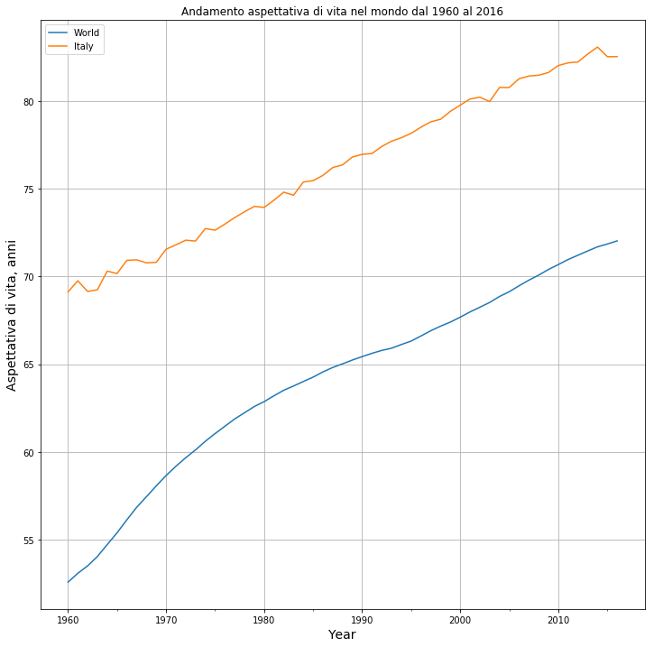

```python
serie_world = expected_world.iloc[0,1:]
serie_world.index = pd.to_datetime(serie_world.index)
serie_italia = italia[italia['Indicator Name'] == 'Life expectancy at birth, total (years)'].iloc[0,1:]
serie_italia.index = pd.to_datetime(serie_italia.index)
both = pd.concat([serie_world, serie_italia], axis = 1)
ax = both.plot(figsize=(12,12), grid = True);
ax.set_title('Andamento aspettativa di vita nel mondo dal 1960 al 2016')
ax.set_xlabel('Year', fontsize=14)
ax.set_ylabel('Aspettativa di vita, anni', fontsize=14);
```

Ma qual è lo Stato del mondo che presenta, nel 2016, l'aspettativa di vita piu' alta? Scopriamolo...

```python
world[world['2016'] == world['2016'].max()]
```

| Country Name | Indicator Name | 1960 | 1961 | 1962 | 1963 | 1964 | 1965 | 1966 | 1967 | 1968 | ... | 2007 | 2008 | 2009 | 2010 | 2011 | 2012 | 2013 | 2014 | 2015 | 2016 |
| --- | --- | --- | --- | --- | --- | --- | --- | --- | --- | --- | --- | --- | --- | --- | --- | --- | --- | --- | --- | --- | --- |
| Hong Kong SAR, China | Life expectancy at birth, total (years) | 66.96 | 67.55 | 68.11 | 68.63 | 69.10 | 69.54 | 69.95 | 70.33 | 70.69 | ... | 82.33 | 82.38 | 82.78 | 82.98 | 83.42 | 83.48 | 83.83 | 83.98 | 84.28 | 84.23 |

1 rows × 58 columns

E' quindi Hong Kong, che presenta un'aspettativa di vita di 84 anni, 8 in piu' rispetto al suo vicino gigante Stato.

```python
China = df2.loc['China']
China[China['Indicator Name'] == 'Life expectancy at birth, total (years)']
```

| Country Name | Indicator Name | 1960 | 1961 | 1962 | 1963 | 1964 | 1965 | 1966 | 1967 | 1968 | ... | 2007 | 2008 | 2009 | 2010 | 2011 | 2012 | 2013 | 2014 | 2015 | 2016 |
| --- | --- | --- | --- | --- | --- | --- | --- | --- | --- | --- | --- | --- | --- | --- | --- | --- | --- | --- | --- | --- | --- |
| China | Life expectancy at birth, total (years) | 43.73 | 44.05 | 44.78 | 45.97 | 47.59 | 49.55 | 51.70 | 53.85 | 55.84 | ... | 74.56 | 74.81 | 75.03 | 75.24 | 75.42 | 75.60 | 75.77 | 75.93 | 76.09 | 76.25 |

1 rows × 58 columns